# ANOVA SOFAStats

## Results of ANOVA test of average height for "sport" groups from "1" to "3"

### Analysis of variance table

| Source | Sum of Squares | df | Mean Sum of Squares | F | p<sup>1</sup> |
| --- | --- | --- | --- | --- | --- |
| Between | 32.811 | 2 | 16.405 | 1,146.524 | < 0.001 (0.000) |
| Within | 28.575 | 1,997 | 0.014 |  |  |

O'Brien's test for homogeneity of variance: < 0.001 (2.851e-4)<sup>2</sup>

### Group summary details

[output not shown]

<sup>1</sup>If p is small, e.g. less than 0.01, or 0.001, you can assume the result is statistically significant i.e. there is a difference between at least two groups. Note: a statistically significant difference may not necessarily be of any practical significance.  
This is a one-tailed result i.e. based on the likelihood of a difference in one particular direction

<sup>2</sup>If the value is small, e.g. less than 0.01, or 0.001, you can assume there is a difference in variance.

<sup>3</sup>There is a 95% chance the population mean is within the confidence interval calculated for this sample. Don't forget, of course, that the population mean could lie well outside the interval bounds. Note - many statisticians argue about the best wording for this conclusion.

<sup>4</sup>Standard Deviation measures the spread of values.

<sup>5</sup>Kurtosis measures the peakedness or flatness of values. Between -2 and 2 means kurtosis is unlikely to be a problem. Between -1 and 1 means kurtosis is quite unlikely to be a problem.

<sup>6</sup>Skew measures the lopsidedness of values. Between -2 and 2 means skew is unlikely to be a problem. Between -1 and 1 means skew is quite unlikely to be a problem.

<sup>7</sup>This provides a single measure of normality. If p is small, e.g. less than 0.01, or 0.001, you can assume the distribution is not strictly normal. Note - it may be normal enough though.

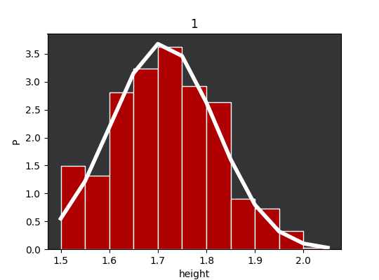

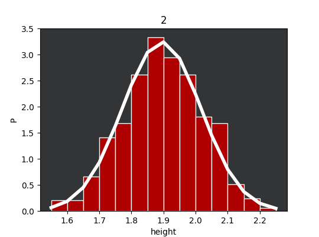

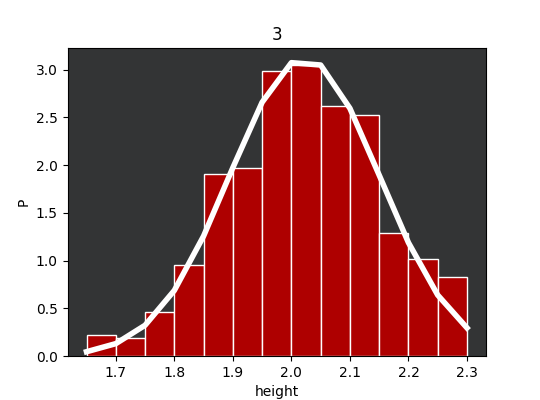

No worked example available for this test